# Time Series Regression: Presidential Approval

### ACF/PACF

I’ve used a function I wrote to produce the ACF/PACF.

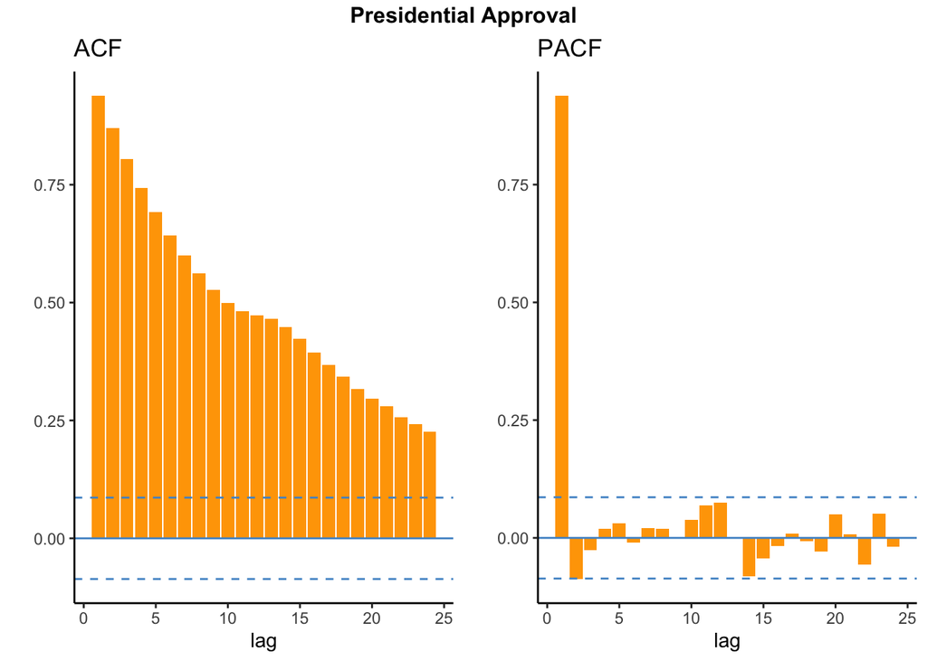

```r
suppressPackageStartupMessages(source("ggacfpacf.R"))

acf.App <- ggacf(AppEcon$Approving, plot.zero="no", lag = 24)
pacf.App <- ggpacf(AppEcon$Approving, plot.zero="no", lag = 24)
title1=textGrob("Presidential Approval", gp=gpar(fontface="bold"))
grid.arrange(acf.App, pacf.App, nrow=1, top=title1)
```

This looks like an ARMA(1,1) process. Let’s estimate an ARMA(1,1) model:

### Estimate and ARMA Model for Presidential Approval

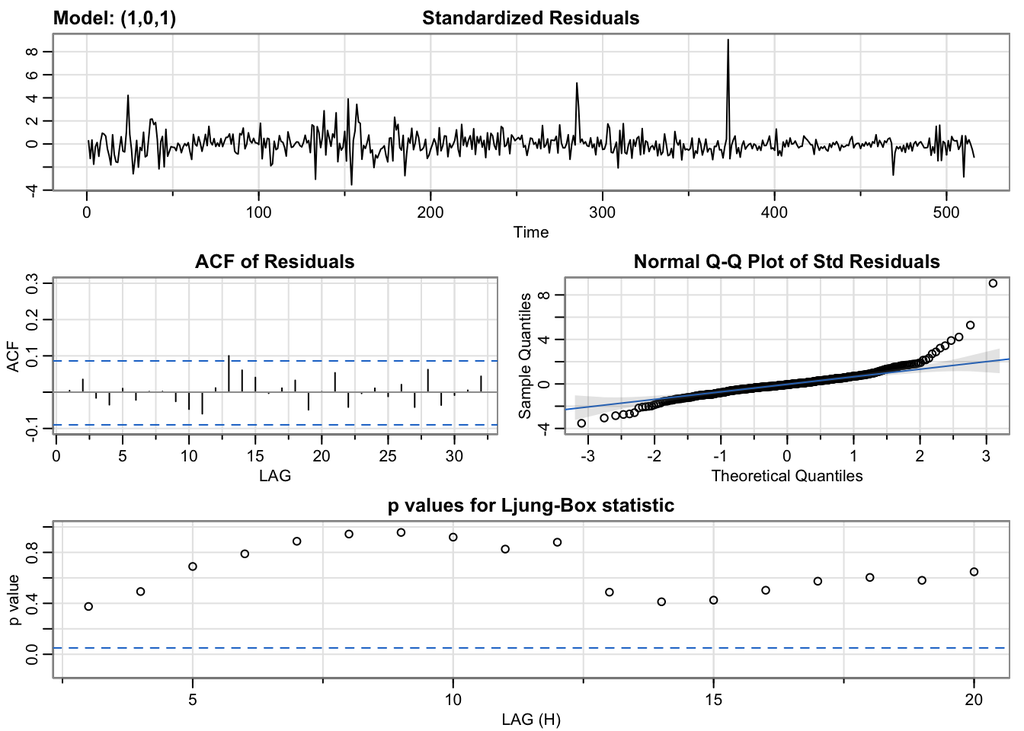

```
## $fit
##
## Call:
## arima(x = xdata, order = c(p, d, q), seasonal = list(order = c(P, D, Q), period = S),
##     xreg = xmean, include.mean = FALSE, transform.pars = trans, fixed = fixed,
##     optim.control = list(trace = trc, REPORT = 1, reltol = tol))
##
## Coefficients:
##          ar1     ma1    xmean
##       0.9281  0.0951  50.3515
## s.e.  0.0171  0.0449   2.4875
##
## sigma^2 estimated as 14.47:  log likelihood = -1422.66,  aic = 2853.32
##
## $degrees_of_freedom
## [1] 513
##
## $ttable
##       Estimate     SE t.value p.value
## ar1     0.9281 0.0171 54.3338  0.0000
## ma1     0.0951 0.0449  2.1158  0.0348
## xmean  50.3515 2.4875 20.2418  0.0000
##
## $AIC
## [1] 5.529699
##
## $AICc
## [1] 5.52979
##
## $BIC
## [1] 5.562614
```

```r
sarima(AppEcon$Approving,p=1,d=0,q=1)
```

The ARMA(1,1) model fares well, but $\phi$ is close to one. Let’s do a unit root test.

### Test for a Unit Root

```r
suppressPackageStartupMessages(source("PGTSadfv2.R"))
adf.tests(AppEcon$Approving, pmax = 14, lmtestorder = 12, type = "constant")
```

```
##
## Dickey Fuller Test Results -- Constant in Test Regression
## ==========================================================================================
## Lags Test Statistic p-value    AIC       BIC    Diff t-value LM p-value Phi 1 Observations
## ------------------------------------------------------------------------------------------
## 14       -3.111      0.026  2,783.359 2,855.041    0.851       0.833    4.841     501
## 13       -3.022      0.034  2,782.106 2,849.571    1.956       0.836    4.567     501
## 12       -2.785      0.061  2,784.035 2,847.284    -0.118      0.394    3.880     501
## 11       -2.828      0.055  2,782.050 2,841.082    -1.683      0.674    3.999     501
## 10       -3.085      0.028  2,782.949 2,837.765    -1.652      0.478    4.759     501
## 9        -3.365      0.013  2,783.738 2,834.337    -0.961      0.366    5.663     501
## 8        -3.565      0.007  2,782.682 2,829.065    -0.090      0.361    6.357     501
## 7        -3.631      0.006  2,780.691 2,822.857    -0.060      0.368    6.594     501
## 6        -3.694      0.004  2,778.694 2,816.644    -0.538      0.490    6.825     501
## 5        -3.851      0.003  2,776.988 2,810.721    0.254       0.564    7.418     501
## 4        -3.871      0.002  2,775.053 2,804.570    -0.617      0.597    7.492     501
## 3        -4.055      0.001  2,773.438 2,798.738    -0.362      0.525    8.224     501
## 2        -4.202      0.001  2,771.570 2,792.653    0.543       0.539    8.830     501
## 1        -4.177      0.001  2,769.867 2,786.734    2.076       0.502    8.725     501
## 0        -3.867      0.002  2,772.182 2,784.832                0.576    7.478     501
## ------------------------------------------------------------------------------------------
## [1] "Phi 1 Critical value .01: 6.43"
## [1] "Phi 1 Critical value .05: 4.59"
## [1] "Phi 1 Critical value .10: 3.78"
```

Which value of $p$ should we choose for the test regression?

- No serial correlation in any test regression
- AIC chooses 1 lag, which happens to be significant
- BIC chooses 0 lags
- We’d choose 13 if we chose to pick the regression where t> 1.60

We have learned that approval appears to be a stationary process.

## Univariate Analysis: DSPIC96_pc_pca, cei_pc, and lei_pc

```r
toplot <- AppEcon %>%
  dplyr::select(Approving, DSPIC96_pc_pca, cei_pc, lei_pc, date)
toplotlong <- toplot %>%
pivot_longer(!date, names_to = "Series", values_to = "Values")
```

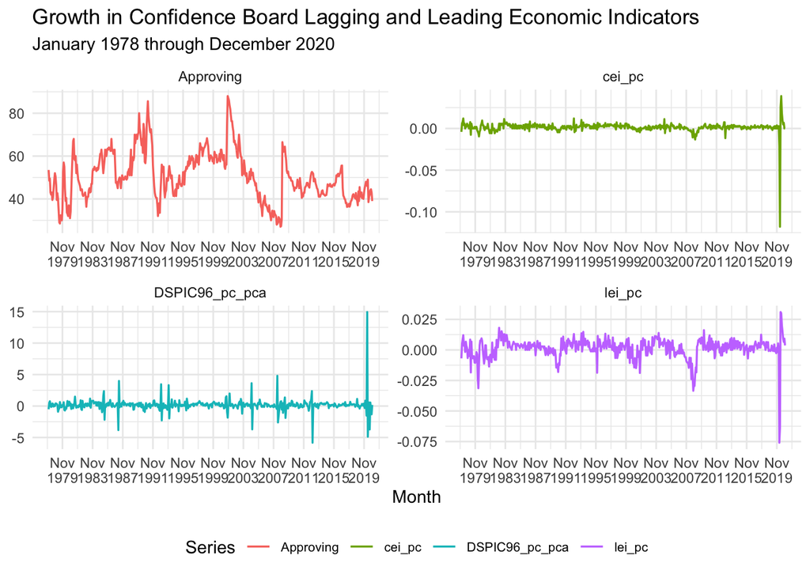

```r
ggplot(toplotlong, aes(x = date, y = Values)) +
  geom_line(aes(color = Series), size = .6) +
   scale_x_date(date_breaks = "48 month", date_labels = "%b\n%Y")+
  theme_minimal() +
  labs(title="Growth in Confidence Board Lagging and Leading Economic Indicators",
       x="Month",
       y=NULL,
       subtitle="January 1978 through December 2020") +
  theme(legend.text = element_text(size=8),
        legend.position = "bottom") +
  facet_wrap(~Series,  scales = "free", ncol = 2)
```

```r
adf.tests(AppEcon$DSPIC96_pc_pca, pmax = 14, lmtestorder = 12, type = "constant")
```

```
##
## Dickey Fuller Test Results -- Constant in Test Regression
## ============================================================================================
## Lags Test Statistic p-value    AIC       BIC    Diff t-value LM p-value  Phi 1  Observations
## --------------------------------------------------------------------------------------------
## 14       -6.668        0    1,403.346 1,475.029    1.055       0.969    22.233      501
## 13       -6.659        0    1,402.494 1,469.960    0.801       0.979    22.174      501
## 12       -6.741        0    1,401.155 1,464.404    1.092       0.980    22.730      501
## 11       -6.733        0    1,400.380 1,459.412    -1.211      0.968    22.678      501
## 10       -7.584        0    1,399.883 1,454.699    0.501       0.932    28.784      501
## 9        -7.891        0    1,398.140 1,448.739    0.225       0.951    31.174      501
## 8        -8.359        0    1,396.192 1,442.574    0.548       0.959    34.990      501
## 7        -8.779        0    1,394.498 1,436.664    0.405       0.948    38.594      501
## 6        -9.917        0    1,392.665 1,430.615    0.995       0.942    49.206      501
## 5       -10.713        0    1,391.670 1,425.403    0.157       0.888    57.402      501
## 4       -12.335        0    1,389.695 1,419.211    0.220       0.655    76.096      501
## 3       -14.884        0    1,387.744 1,413.043    3.574       0.884    110.768     501
## 2       -15.473        0    1,398.484 1,419.567    0.374       0.099    119.708     501
## 1       -20.940        0    1,396.625 1,413.492    3.555       0.124    219.253     501
## 0       -29.950        0    1,407.179 1,419.829                0.004    448.492     501
## --------------------------------------------------------------------------------------------
## [1] "Phi 1 Critical value .01: 6.43"
## [1] "Phi 1 Critical value .05: 4.59"
## [1] "Phi 1 Critical value .10: 3.78"
```

```r
adf.tests(AppEcon$cei_pc, pmax = 14, lmtestorder = 12, type = "constant")
```

```
##
## Dickey Fuller Test Results -- Constant in Test Regression
## ==============================================================================================
## Lags Test Statistic p-value    AIC        BIC     Diff t-value LM p-value  Phi 1  Observations
## ----------------------------------------------------------------------------------------------
## 14       -4.765        0    -3,602.710 -3,531.028    0.846       0.963    11.381      501
## 13       -4.693        0    -3,603.972 -3,536.506    0.929       0.968    11.042      501
## 12       -4.601        0    -3,605.084 -3,541.834    0.713       0.935    10.614      501
## 11       -4.553        0    -3,606.561 -3,547.529    -0.126      0.925    10.391      501
## 10       -4.687        0    -3,608.545 -3,553.729    -0.636      0.926    11.008      501
## 9        -5.016        0    -3,610.131 -3,559.532    -0.854      0.953    12.590      501
## 8        -5.578        0    -3,611.386 -3,565.003    -1.883      0.916    15.558      501
## 7        -6.615        0    -3,609.781 -3,567.614    -1.037      0.705    21.895      501
## 6        -7.629        0    -3,610.687 -3,572.738    -1.234      0.628    29.103      501
## 5        -8.899        0    -3,611.141 -3,577.408    -0.519      0.518    39.598      501
## 4       -10.042        0    -3,612.868 -3,583.351    -0.345      0.501    50.419      501
## 3       -11.495        0    -3,614.747 -3,589.448    -0.013      0.564    66.071      501
## 2       -13.441        0    -3,616.747 -3,595.664    0.101       0.143    90.336      501
## 1       -16.742        0    -3,618.737 -3,601.870    2.880       0.666    140.152     501
## 0       -19.596        0    -3,612.463 -3,599.814                0.162    191.998     501
## ----------------------------------------------------------------------------------------------
## [1] "Phi 1 Critical value .01: 6.43"
## [1] "Phi 1 Critical value .05: 4.59"
## [1] "Phi 1 Critical value .10: 3.78"
```

```r
adf.tests(AppEcon$lei_pc, pmax = 14, lmtestorder = 12, type = "constant")
```

```
##
## Dickey Fuller Test Results -- Constant in Test Regression
## =============================================================================================
## Lags Test Statistic p-value    AIC        BIC     Diff t-value LM p-value Phi 1  Observations
## ---------------------------------------------------------------------------------------------
## 14       -4.523        0    -3,498.002 -3,426.320    -0.837      0.870    10.232     501
## 13       -4.815        0    -3,499.279 -3,431.814    -0.113      0.880    11.592     501
## 12       -4.964        0    -3,501.266 -3,438.017    0.026       0.859    12.322     501
## 11       -5.091        0    -3,503.265 -3,444.233    2.194       0.880    12.961     501
## 10       -4.720        0    -3,500.346 -3,445.530    0.025       0.886    11.141     501
## 9        -4.838        0    -3,502.346 -3,451.746    0.077       0.907    11.710     501
## 8        -4.976        0    -3,504.340 -3,457.957    -0.737      0.919    12.387     501
## 7        -5.295        0    -3,505.786 -3,463.619    -0.454      0.902    14.027     501
## 6        -5.642        0    -3,507.576 -3,469.627    -0.087      0.775    15.920     501
## 5        -5.901        0    -3,509.568 -3,475.836    -1.428      0.937    17.413     501
## 4        -6.605        0    -3,509.506 -3,479.989    -1.363      0.817    21.813     501
## 3        -7.428        0    -3,509.628 -3,484.329    -1.110      0.728    27.590     501
## 2        -8.356        0    -3,510.386 -3,489.303    -3.293      0.671    34.915     501
## 1       -10.771        0    -3,501.574 -3,484.708    -0.199      0.030    58.002     501
## 0       -12.461        0    -3,503.534 -3,490.885                0.083    77.637     501
## ---------------------------------------------------------------------------------------------
## [1] "Phi 1 Critical value .01: 6.43"
## [1] "Phi 1 Critical value .05: 4.59"
## [1] "Phi 1 Critical value .10: 3.78"
```

# Regression Models for Stationary Time Series with Weakly Exogenous Regressors

Our goal is to assess the long and short run relationships between our independent variables, $\mathbf{x}$ and our dependent variable $y$. Given the asymptotic linear regression assumptions, we can estimate a number of time series regression models and draw inference using standard inferential tools.

Step 1. The first step in dynamic specification is to choose a model specification relating some dependent variable $y$ to a set of explanatory variables $\mathbf{z_t}$, where $\mathbf{z_t}$ may include current and lagged values of $\mathbf{x}$ and lagged values of $y$. The specification we choose determines the structural relationship imposed on the data, i.e., it determines how $y$ is allowed to respond to $x$ – at how many and which lags – and its own past behavior. Our task is to select a specification sufficiently general as to encompass the underlying data generating process such that the model does not violate ATS1-6.

Step 1. In step two, the analyst checks the statistical adequacy of the model given the data with tests designed to determine whether the time series regression assumptions are met.

Step 3. In step three the analyst tests restrictions on the general model in order to produce a more parsimonious specification for inference. While the general model could be used for inference, imposing (valid) restrictions on the general model will result in more efficient estimates.

Step 4. The last step, step four, is to draw inferences from the model.

# Step 1: Estimate A Plausible General Model of Presidential Approval

A. Use theory to determine the variables to include in the model and the highest reasonable lag length for which $x$ and lagged values of $y$ might influence the present value of $y$.

B. Specify a model consistent with that knowledge. The general model specification can be one of two flavors: the autoregressive distributed lag model (ADL) or the generalized error correction model (GECM.) These specifications encompass a wide range of dynamic structures.

## Autoregressive Distributed Lag Model

The ADL specifies that $y$ is a function of contemporaneous and some number of lags ($q$) of the $n$ explanatory variables, $x$, and some number of lags ($p$) of the dependent variable, $y$:
$$y_t=\alpha_0 + \sum_{i=1}^p\alpha_i y_{t-i} + \sum_{j=1}^n\sum_{i=0}^q\beta_{j,i} x_{j,t-i} +
\varepsilon_t$$
where $\mathbf{z}_t=(y_{t-1},...,y_{t-i}; x_{j,t},...,x_{j,t-i})$; $p$ refers to the number of lags of $y_t$; $q$ the number of lags of $x_t$; $n$ the number of independent variables in the model and the asymptotic regression assumptions hold.

The larger $p$ and $q$, the more general the dynamic structure permitted in the ADL. Often $p=1$ and $q=1$. In this case, the model specifies that contemporaneous and one lag of the $n$ regressors have a direct effect on $y$ and that they have an additional indirect effect by virtue of the inclusion of one lag of $y$.

### Trends, Seasonality, Shocks, and Structural Breaks

Both the ADL and GECM can accommodate deterministic trends, structural breaks, and seasonality in a straightforward manner.

- If $y_t$ contains a linear deterministic trend, include $t$ as a regressor and interpret the quantities from the resulting model as if we had detrended the data first. (Include $t$ in the moodel if any $x$ are trending to allow movement around the trend in $x$ to influence $y$.)
- Add dummy variables that account for the influence of the break should be included.
  - A pulse dummy variable, where $Dp=0$ prior to the break, 1 at the point of the break, and 0 in all subsequent periods, will accommodate the effect of a temporary shock.
  - A step dummy, where $Dl=0$ before the break and 1 at the point of the break and in all subsequent periods, will accommodate the effect of a shock that permanently altered the mean of $y$.
- Seasonal dummies can be included in the regression, e.g., if $s=12$ we can include a dummy for each of the 12 months of the year (and suppress the constant). Including seasonal dummies in a regression can be interpreted as deseasonalizing the data.

### Estimate an ADL

Estimate the model using `dynlm()` in the package by the same name. We will need to make the data ts/mts class. We’re going to start in January 1978 and end in December 2020.

```r
AppEcon.ts <- ts(AppEcon, start = c(1978,1), end = c(2020,12), freq = 12)
```

```r
ADL1 <- dynlm(Approving~L(Approving,1) +
               DSPIC96_pc_pca +L(DSPIC96_pc_pca, 1) + L(DSPIC96_pc_pca, 2)+
               lei_pc + L(lei_pc, 1) + L(lei_pc, 2) +
               cei_pc + L(cei_pc, 1) + L(cei_pc, 2) +
               Reagan + BushI + Clinton + BushII + Obama + Trump +
               Honey + Inaug +  RAss + IraqKuwait + Desert + Lehman +
               Sept11 + Mueller  + Impeach1 + Impeach2 + CovidP + CovidS, data=AppEcon.ts)
summary(ADL1)
```

Time series regression with “ts” data: Start = 1978(3), End = 2020(12)

Call: dynlm(formula = Approving ~ L(Approving, 1) + DSPIC96_pc_pca + L(DSPIC96_pc_pca, 1) + L(DSPIC96_pc_pca, 2) + lei_pc + L(lei_pc, 1) + L(lei_pc, 2) + cei_pc + L(cei_pc, 1) + L(cei_pc, 2) + Reagan + BushI + Clinton + BushII + Obama + Trump + Honey + Inaug + RAss + IraqKuwait + Desert + Lehman + Sept11 + Mueller + Impeach1 + Impeach2 + CovidP + CovidS, data = AppEcon.ts)

Residuals: Min 1Q Median 3Q Max -15.0519 -1.6718 -0.2074 1.7427 28.2560

Residual standard error: 3.527 on 485 degrees of freedom Multiple R-squared: 0.9063, Adjusted R-squared: 0.9009 F-statistic: 167.5 on 28 and 485 DF, p-value: < 2.2e-16

## Generalized Error Correction Model

The generalized error correction model (GECM) is a linear transformation of the ADL and thus while it has an alternative form, *it implies exactly the same dynamic structure*. The dependent variable in the GECM is the change in $y$ and is a function of (short run) changes in $x$ and lagged values of $y$ and $x$. The main attraction of the GECM is that this particular reparameterization of the ADL isolates the rate at which $y$ changes to return to equilibrium after a change in $x$ or any shocks (the error correction rate) and its standard error.

To illustrate the equivalence of the ADL and GECM we begin with the ADL(1,1;1):
$$\begin{equation}
y_t=\alpha_0 + \alpha_1 y_{t-1} + \beta_0 x_t +\beta_1 x_{t-1} + \varepsilon_t.
\end{equation}$$
Subtract $y_{t-1}$ from both sides:
$$\begin{equation}
\Delta y_t=\alpha_0 +( \alpha_1-1) y_{t-1} + \beta_0 x_t +\beta_1 x_{t-1} + \varepsilon_t.
\end{equation}$$
Add and subtract $\beta_0x_{t-1}$ on the right side:
$$\begin{equation}
\Delta y_t=\alpha_0 +(\alpha_1-1) y_{t-1} + \beta_0 \Delta x_t +(\beta_0 + \beta_1) x_{t-1} + \varepsilon_t.
\end{equation}$$
Collecting terms:
$$\begin{equation}
\Delta y_t = \alpha_0 + \alpha_1^* y_{t-1} + \beta_0^* \Delta x_t + \beta_1^* x_{t-1} + \varepsilon_t
\end{equation}$$
where $\alpha_1^* = (\alpha_1 - 1)$, $\beta_0^* = \beta_0$, and $\beta_1^* = \beta_0 + \beta_1$. Importantly, the fit of the model is identical to that of the ADL, although the $R^2$ will be different because the dependent variable is different. Similarly, the standard errors of comparable estimates will be the same.

To see where the error correction model gets its name add and subtract $( \alpha_1-1) x_{t-1}$ on the right side of the above equation before where we collected terms and regroup terms:
$$\begin{equation}
\Delta y_t=\alpha_0 +( \alpha_1-1) (y_{t-1} -x_{t-1})+ \beta_0 \Delta x_t +(\beta_0 + \beta_1+\alpha_1-1) x_{t-1} + \varepsilon_t.
\end{equation}$$
In this form it is easy to see that the difference between $y$ and $x$ in the previous period determines change in $y$ in the current period (controlling for the other variables in the model). Note that while it appears as though the equilibrium relationship between $x$ and $y$ is one-to-one, the additional $x_{t-1}$ on the righthand side of the model allows the nature of the equilibrium relationship to be more general.

### Estimate the ADL for Presidential Approval as a GECM:

To estimate a comparable GECM, we will need one lag of $y_t$, one lag of each $x_{jt}$ and one first difference of each $x_{jt}$.

```r
GECM1 <- dynlm(d(Approving)~L(Approving,1) +
                 L(DSPIC96_pc_pca, 1) + d(DSPIC96_pc_pca) + L(d(DSPIC96_pc_pca), 1) +
                 L(lei_pc, 1) + d(lei_pc) + L(d(lei_pc, 1)) +
                 L(cei_pc, 1) +  d(cei_pc) + L(d(cei_pc, 1)) +
                 Reagan + BushI + Clinton + BushII + Obama + Trump +
                 Honey + Inaug +  RAss + IraqKuwait + Desert + Lehman +
                 Sept11 + Mueller  + Impeach1 + Impeach2 + CovidP + CovidS, data=AppEcon.ts)
summary(GECM1)
```

## Compare the ADL and GECM

```r
ALL <- stargazer(ADL1, GECM1,
          type = "html",
          column.labels =c("ADL", "GECM"),
          dep.var.labels = c("Approval","D-Approval"),
          model.names = FALSE)
```

|  | *Dependent variable:* |  |
| --- | --- | --- |
|  | Approval | D-Approval |
|  | ADL | GECM |
|  | (1) | (2) |
| L(Approving, 1) | 0.888*** | -0.112*** |
|  | (0.017) | (0.017) |
| DSPIC96_pc_pca | 0.246 |  |
|  | (0.190) |  |
| L(DSPIC96_pc_pca, 1) | 0.345* | 0.974** |
|  | (0.199) | (0.405) |
| L(DSPIC96_pc_pca, 2) | 0.384** |  |
|  | (0.187) |  |
| lei_pc | 10.399 |  |
|  | (32.885) |  |
| d(DSPIC96_pc_pca) |  | 0.246 |
|  |  | (0.190) |
| L(d(DSPIC96_pc_pca), 1) |  | -0.384** |
|  |  | (0.187) |
| L(lei_pc, 1) | -36.845 | -91.415** |
|  | (34.211) | (39.976) |
| L(lei_pc, 2) | -64.968* |  |
|  | (34.205) |  |
| cei_pc | 17.116 |  |
|  | (37.565) |  |
| d(lei_pc) |  | 10.399 |
|  |  | (32.885) |
| L(d(lei_pc, 1)) |  | 64.968* |
|  |  | (34.205) |
| L(cei_pc, 1) | 43.161 | 204.707*** |
|  | (38.650) | (69.378) |
| L(cei_pc, 2) | 144.430*** |  |
|  | (37.685) |  |
| d(cei_pc) |  | 17.116 |
|  |  | (37.565) |
| L(d(cei_pc, 1)) |  | -144.430*** |
|  |  | (37.685) |
| Reagan | 2.095*** | 2.095*** |
|  | (0.751) | (0.751) |
| BushI | 1.658* | 1.658* |
|  | (0.897) | (0.897) |
| Clinton | 2.175*** | 2.175*** |
|  | (0.757) | (0.757) |
| BushII | 0.870 | 0.870 |
|  | (0.732) | (0.732) |
| Obama | 1.860** | 1.860** |
|  | (0.742) | (0.742) |
| Trump | -0.127 | -0.127 |
|  | (0.888) | (0.888) |
| Honey | 0.114 | 0.114 |
|  | (0.073) | (0.073) |
| Inaug | 3.075* | 3.075* |
|  | (1.669) | (1.669) |
| RAss | 7.060* | 7.060* |
|  | (3.609) | (3.609) |
| IraqKuwait | 1.673 | 1.673 |
|  | (1.757) | (1.757) |
| Desert | 10.701*** | 10.701*** |
|  | (2.169) | (2.169) |
| Lehman | -1.512 | -1.512 |
|  | (3.650) | (3.650) |
| Sept11 | 11.281*** | 11.281*** |
|  | (1.885) | (1.885) |
| Mueller | 7.745** | 7.745** |
|  | (3.587) | (3.587) |
| Impeach1 | 3.118 | 3.118 |
|  | (3.588) | (3.588) |
| Impeach2 | 2.982 | 2.982 |
|  | (3.593) | (3.593) |
| CovidP | 1.414 | 1.414 |
|  | (4.263) | (4.263) |
| CovidS | -0.979 | -0.979 |
|  | (1.424) | (1.424) |
| Constant | 4.501*** | 4.501*** |
|  | (1.724) | (1.724) |
| Observations | 514 | 514 |
| R<sup>2</sup> | 0.906 | 0.220 |
| Adjusted R<sup>2</sup> | 0.901 | 0.175 |
| Residual Std. Error (df = 485) | 3.527 | 3.527 |
| F Statistic (df = 28; 485) | 167.534*** | 4.879*** |
| *Note:* | p<0.1; p<0.05; p<0.01 |  |

The results are the same if we take into account the relationships between the parameters in the two models:

- Coefficient on contemporaneous $x_t$ in ADL = coefficient on $\Delta x_t$ in GECM
- Sum of all levels coefficients on $x_t$ in ADL = coefficient on $x_{t-1}$ in GECM

# Step Two: Diagnostics

## TS1: Linear with Constant Parameters

Plots of the observed versus predicted values from the estimated model should be randomly distributed around a 45 degree line while plots of residuals versus predicted values (or values of individual $x_{jt}$) should be distributed randomly around zero with a constant variance.

### Plot of Predicted v Actual Values of Approval

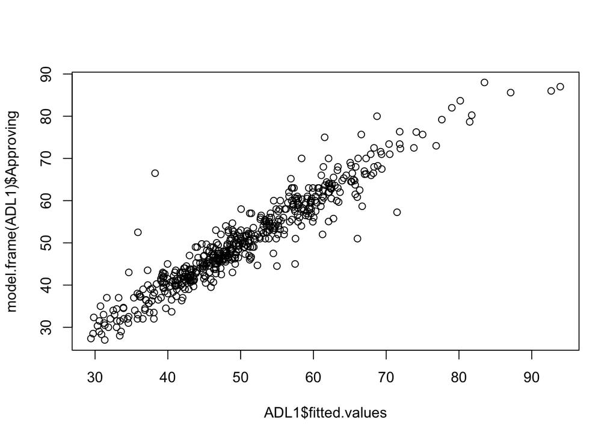

```r
plot(ADL1$fitted.values,model.frame(ADL1)$Approving)
```

### Plot of Predited v Residuals

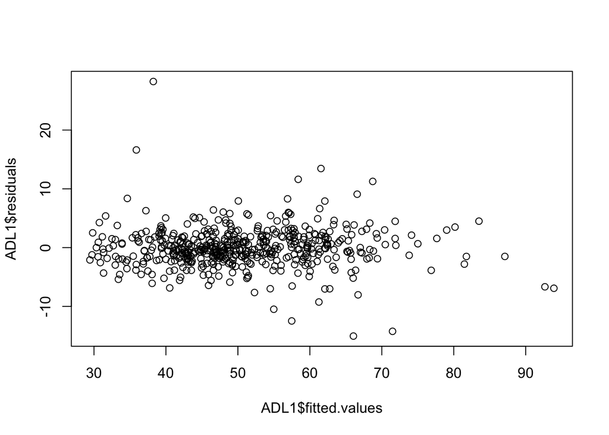

```r
plot(ADL1$fitted.values,ADL1$residuals)
```

### Ramsey’s RESET Test

The RESET test is a formal test for misspecification due to incorrect functional form and omitted variables, as well as correlation between $z_t$ and $\mu_t$. You estimate an auxiliary regression of $y_t$ on the squared (and possibly cubed and higher order functions) of the residuals from the original model specification and use an F-test to evaluate the joint null hypothesis that the coefficients on the powers of fitted values are all zero. If the null hypothesis is rejected, it could be due to either non-linearity or an omitted variable.

The `resettest()` function in the lmtest package will do this for you.

resettest(formula, power = 2:3, type = c(“fitted”, “regressor”, “princomp”), data = list(), vcov = NULL, …)

- The `formula` argument requires the formula for the regression to be tested.
- The `power` argument tells the function what power of residuals to include in the test regression
- `type` specifies whether powers of the fitted response, the regressor variables (factors are left out), or the first principal component of the regressor matrix should be included in the extended model.
- `data` an optional data frame containing the variables in the model. By default the variables are taken from the environment which resettest is called from.
- `vcov` optional arguments to be passed to waldtest for carrying out the F test.

```r
resettest(ADL1, power=2, type="regressor", data=AppEcon.ts)
```

```
##
##  RESET test
##
## data:  ADL1
## RESET = 0.70865, df1 = 28, df2 = 457, p-value = 0.8655
```

### EFP Tests

efp(formula, data, type = , h = 0.15, dynamic = FALSE, rescale = TRUE, lrvar = FALSE, vcov = NULL)

- `formula` a symbolic description for the model to be tested.
- `data` an optional data frame containing the variables in the model. By default the variables are taken from the environment which efp is called from.
- `type` specifies which type of fluctuation process will be computed, the default is “Rec-CUSUM”.
- `h` a numeric from interval (0,1) specifying the bandwidth. This determines the size of the data window relative to sample size (for MOSUM and ME processes only).
- `dynamic` If TRUE the lagged observations are included as a regressor.
- `rescale` If TRUE the estimates will be standardized by the regressor matrix of the corresponding subsample; if FALSE the whole regressor matrix will be used. (only if type is either “RE” or “ME”)
- `lrvar` Should a long-run variance estimator be used for the residuals? By default, the standard OLS variance is employed. Alternatively, lrvar can be used. If lrvar is character (“Andrews” or “Newey-West”), then the corresponding type of long-run variance is used. (The argument is ignored for the score-based tests where gefp should be used instead.)
- `vcov`a function to extract the covariance matrix for the coefficients of the fitted model (only for “RE” and “ME”).

After obtaining the efp process use the `plot()` function for a visual of the results and the `sctest()` function in strucchange to test the null of constancy in the efp.

#### Cumulative Sum of Residuals

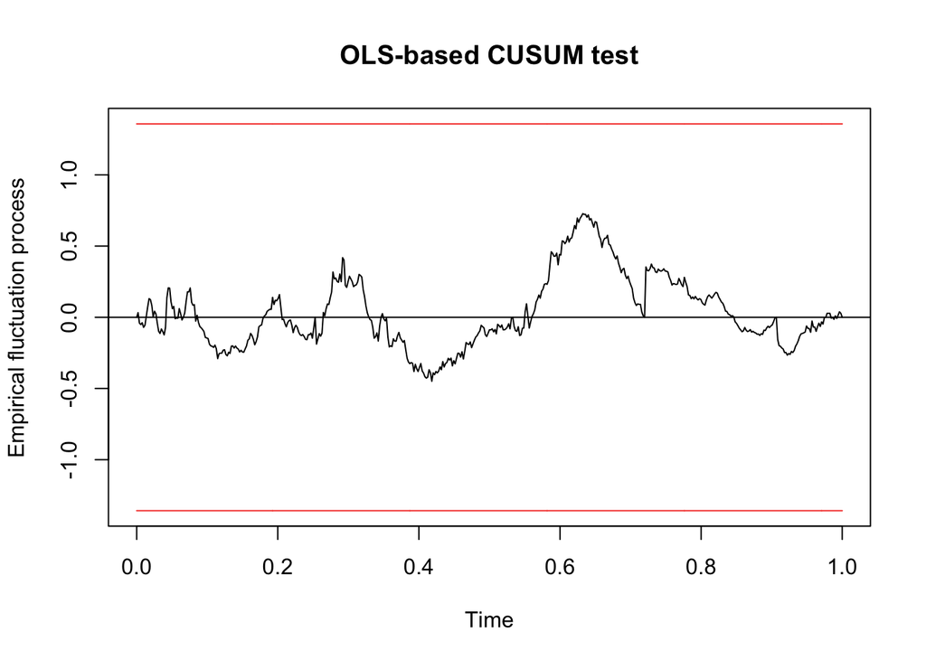

```r
my_efp <- efp(ADL1, type="OLS-CUSUM", data=AppEcon.ts)
plot(my_efp)
```

```r
sctest(my_efp)
```

```
##
##  OLS-based CUSUM test
##
## data:  my_efp
## S0 = 0.72771, p-value = 0.6647
```

#### Recursive Parameter Estimates

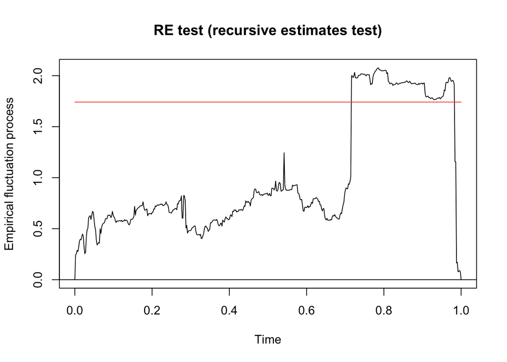

```r
ADL1 <- dynlm(Approving~L(Approving,1) +
               DSPIC96_pc_pca +L(DSPIC96_pc_pca, 1) + L(DSPIC96_pc_pca, 2)+
               lei_pc + L(lei_pc, 1) + L(lei_pc, 2) +
               cei_pc + L(cei_pc, 1) + L(cei_pc, 2), data=AppEcon.ts)
efp_fluc <- efp(ADL1, type="RE", data=AppEcon.ts)
plot(efp_fluc)
```

```r
efp_tbl <- as_tibble(efp_fluc$process)

    efp_tbl$date <- seq(as.Date("1978/12/1"), as.Date("2020/12/1"), "months")
    efp_tbl
```

| (Intercept) | L(Approving, 1) | DSPIC96_pc_pca | L(DSPIC96_pc_pca, 1) | L(DSPIC96_pc_pca, 2) | lei_pc | L(lei_pc, 1) | L(lei_pc, 2) | cei_pc | L(cei_pc, 1) | L(cei_pc, 2) | date |
| --- | --- | --- | --- | --- | --- | --- | --- | --- | --- | --- | --- |
| 0.0000000000 | 0.0000000000 | 0.000000e+00 | 0.000000000 | 0.000000000 | 0.0000000000 | 0.000000000 | 0.0000000000 | 0.000000000 | 0.000000000 | 0.0000000000 | 1978-12-01 |
| 0.1264112695 | -0.1290702608 | -1.909120e-01 | -0.118568519 | -0.134187497 | 0.0160733732 | -0.072682737 | -0.1025853279 | 0.207954329 | -0.051084452 | -0.2456418522 | 1979-01-01 |
| 0.1217509531 | -0.2229504785 | -2.533608e-01 | -0.153049653 | -0.211586289 | 0.1494081274 | 0.018947520 | -0.0718361185 | 0.117987821 | -0.049635416 | -0.2529776630 | 1979-02-01 |
| 0.1947831793 | -0.2087386859 | -2.441569e-01 | -0.145891114 | -0.184513151 | 0.1725291153 | 0.003764645 | -0.0979342263 | 0.114841220 | -0.066896588 | -0.2876227435 | 1979-03-01 |
| 0.2143148910 | -0.2463520388 | -5.520892e-02 | -0.180268950 | -0.134080729 | 0.2158529097 | 0.022566650 | -0.0229955397 | 0.208446493 | -0.060538005 | -0.2764721831 | 1979-04-01 |
| 0.1887779236 | -0.3174222562 | 3.719430e-02 | 0.051628568 | -0.121415325 | -0.1081132622 | 0.235396618 | 0.0290457755 | 0.227051191 | 0.053829158 | -0.2321660608 | 1979-05-01 |
| 0.0817096090 | -0.3765754392 | 1.094391e-01 | 0.113601799 | 0.051703465 | -0.0500658148 | 0.135641612 | 0.2681690149 | 0.043500540 | -0.035335592 | -0.2859625113 | 1979-06-01 |
| 0.0489589528 | -0.3958776703 | 9.860649e-02 | 0.123776008 | 0.057468084 | 0.0112351868 | 0.172203469 | 0.2439377770 | 0.031137301 | -0.073168862 | -0.3045150549 | 1979-07-01 |
| 0.1080730173 | -0.3911177485 | 8.761689e-02 | 0.176889540 | 0.026968813 | -0.0025905761 | 0.117293443 | 0.2424411574 | 0.057165383 | -0.073261243 | -0.2723197388 | 1979-08-01 |
| 0.0761278183 | -0.4181319287 | 9.347965e-02 | 0.185682287 | 0.003092158 | 0.0149158430 | 0.126557697 | 0.2795348523 | 0.057643885 | -0.073011292 | -0.2626196366 | 1979-09-01 |

[output cut: 495 more lines]

```r
    colnames(efp_tbl) <- c("Intercept","Lag Approval","Disp Income","Lag Disp Income", "Lag 2 Disp Income", "LEI % Change", "Lag LEI % Change", "Lag 2 LEI % Change", "CEI % Change", "Lag CEI % Change", "Lag 2 CEI % Change", "Date")
    efp_tbl
```

| Intercept | Lag Approval | Disp Income | Lag Disp Income | Lag 2 Disp Income | LEI % Change | Lag LEI % Change | Lag 2 LEI % Change | CEI % Change | Lag CEI % Change | Lag 2 CEI % Change | Date |
| --- | --- | --- | --- | --- | --- | --- | --- | --- | --- | --- | --- |
| 0.0000000000 | 0.0000000000 | 0.000000e+00 | 0.000000000 | 0.000000000 | 0.0000000000 | 0.000000000 | 0.0000000000 | 0.000000000 | 0.000000000 | 0.0000000000 | 1978-12-01 |
| 0.1264112695 | -0.1290702608 | -1.909120e-01 | -0.118568519 | -0.134187497 | 0.0160733732 | -0.072682737 | -0.1025853279 | 0.207954329 | -0.051084452 | -0.2456418522 | 1979-01-01 |
| 0.1217509531 | -0.2229504785 | -2.533608e-01 | -0.153049653 | -0.211586289 | 0.1494081274 | 0.018947520 | -0.0718361185 | 0.117987821 | -0.049635416 | -0.2529776630 | 1979-02-01 |
| 0.1947831793 | -0.2087386859 | -2.441569e-01 | -0.145891114 | -0.184513151 | 0.1725291153 | 0.003764645 | -0.0979342263 | 0.114841220 | -0.066896588 | -0.2876227435 | 1979-03-01 |
| 0.2143148910 | -0.2463520388 | -5.520892e-02 | -0.180268950 | -0.134080729 | 0.2158529097 | 0.022566650 | -0.0229955397 | 0.208446493 | -0.060538005 | -0.2764721831 | 1979-04-01 |
| 0.1887779236 | -0.3174222562 | 3.719430e-02 | 0.051628568 | -0.121415325 | -0.1081132622 | 0.235396618 | 0.0290457755 | 0.227051191 | 0.053829158 | -0.2321660608 | 1979-05-01 |
| 0.0817096090 | -0.3765754392 | 1.094391e-01 | 0.113601799 | 0.051703465 | -0.0500658148 | 0.135641612 | 0.2681690149 | 0.043500540 | -0.035335592 | -0.2859625113 | 1979-06-01 |
| 0.0489589528 | -0.3958776703 | 9.860649e-02 | 0.123776008 | 0.057468084 | 0.0112351868 | 0.172203469 | 0.2439377770 | 0.031137301 | -0.073168862 | -0.3045150549 | 1979-07-01 |
| 0.1080730173 | -0.3911177485 | 8.761689e-02 | 0.176889540 | 0.026968813 | -0.0025905761 | 0.117293443 | 0.2424411574 | 0.057165383 | -0.073261243 | -0.2723197388 | 1979-08-01 |
| 0.0761278183 | -0.4181319287 | 9.347965e-02 | 0.185682287 | 0.003092158 | 0.0149158430 | 0.126557697 | 0.2795348523 | 0.057643885 | -0.073011292 | -0.2626196366 | 1979-09-01 |

[output cut: 495 more lines]

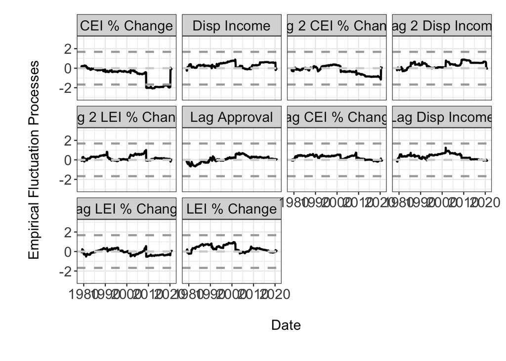

```r
    efp_tbl <- efp_tbl[,c("Lag Approval","Disp Income","Lag Disp Income", "Lag 2 Disp Income", "LEI % Change", "Lag LEI % Change", "Lag 2 LEI % Change", "CEI % Change", "Lag CEI % Change", "Lag 2 CEI % Change", "Date")]

    efp_tbl_long <- efp_tbl %>%
      pivot_longer(!Date, names_to = "Parameter", values_to = "Estimate")
ggplot(efp_tbl_long, aes(x = Date, y = Estimate)) +
      geom_line(lwd = 1) +
      ylim(-3,3) +
      theme_bw() +
      geom_hline(yintercept = 0, lwd = 1, lty = 2, col = "lightgray") +
      geom_hline(yintercept = 1.67525, lwd = 1, lty = 2, col = "darkgray") +
      geom_hline(yintercept = -1.67525, lwd = 1, lty = 2, col = "darkgray") +
      facet_wrap(~Parameter) +
      theme(plot.margin=unit(c(t = 0.5, r = 0.5, b = 1, l =1),"cm")) +
      labs(x = "\n Date", y = "Empirical Fluctuation Processes\n ") +
      theme(axis.title = element_text(size = 14)) +
      theme(axis.text = element_text(size = 14)) +
      theme(strip.text.x = element_text(size = 14)) +
      theme(legend.position = "none")
```

## TS2: Stationarity and Weak Dependence

Evaluate the parameters on lagged Approval. Easy here, is it less than one in absolute value? Yes.

## TS3: Zero Conditional Mean

### Evaluate Weak Exogeneity

See also Ramsey’s RESET test above.

1. Estimate marginal model for disposable income.

```r
DispInc <- dynlm( DSPIC96_pc_pca ~ L(DSPIC96_pc_pca, 1) + L(DSPIC96_pc_pca, 2)  + inflation + L(inflation, 1) + UNRATE + L(UNRATE, 1), data = AppEcon.ts)
summary(DispInc)
```

```
##
## Time series regression with "ts" data:
## Start = 1978(3), End = 2020(12)
##
## Call:
## dynlm(formula = DSPIC96_pc_pca ~ L(DSPIC96_pc_pca, 1) + L(DSPIC96_pc_pca,
##     2) + inflation + L(inflation, 1) + UNRATE + L(UNRATE, 1),
##     data = AppEcon.ts)
##
## Residuals:
##     Min      1Q  Median      3Q     Max
## -5.4565 -0.2735 -0.0022  0.2972  4.0914
##
## Coefficients:
##                      Estimate Std. Error t value Pr(>|t|)
## (Intercept)           0.34959    0.12712   2.750  0.00617 **
## L(DSPIC96_pc_pca, 1) -0.26521    0.03527  -7.519 2.53e-13 ***
## L(DSPIC96_pc_pca, 2) -0.09966    0.03489  -2.856  0.00446 **
## inflation            -2.58972    1.12029  -2.312  0.02120 *
## L(inflation, 1)      -0.81375    1.13776  -0.715  0.47480
## UNRATE                1.14498    0.06622  17.292  < 2e-16 ***
## L(UNRATE, 1)         -1.14801    0.06649 -17.266  < 2e-16 ***
## ---
## Signif. codes:  0 '***' 0.001 '**' 0.01 '*' 0.05 '.' 0.1 ' ' 1
##
## Residual standard error: 0.7446 on 507 degrees of freedom
## Multiple R-squared:  0.4638, Adjusted R-squared:  0.4574
## F-statistic: 73.08 on 6 and 507 DF,  p-value: < 2.2e-16
```

```r
DIresids <- DispInc$residuals
```

2. Make sure there is no serial correlation. (More below.)

```r
bgtest(DispInc, order=24, type="Chisq")
```

```
##
##  Breusch-Godfrey test for serial correlation of order up to 24
##
## data:  DispInc
## LM test = 34.951, df = 24, p-value = 0.06913
```

```r
bgtest(DispInc, order=12, type="Chisq")
```

```
##
##  Breusch-Godfrey test for serial correlation of order up to 12
##
## data:  DispInc
## LM test = 17.271, df = 12, p-value = 0.1397
```

```r
bgtest(DispInc, order=6, type="Chisq")
```

```
##
##  Breusch-Godfrey test for serial correlation of order up to 6
##
## data:  DispInc
## LM test = 9.9516, df = 6, p-value = 0.1267
```

3. Estimate Test Regression of residuals from conditional model on residuals from marginal model and lagged Approval.

```r
ExTest <- dynlm(ADL1$residuals~ DispInc$residuals + L(model.frame(ADL1)$Approving))
(RExTest <- summary(ExTest))
```

```
##
## Time series regression with "ts" data:
## Start = 1978(4), End = 2020(12)
##
## Call:
## dynlm(formula = ADL1$residuals ~ DispInc$residuals + L(model.frame(ADL1)$Approving))
##
## Residuals:
##     Min      1Q  Median      3Q     Max
## -14.932  -1.781  -0.170   1.512  32.708
##
## Coefficients:
##                                  Estimate Std. Error t value Pr(>|t|)
## (Intercept)                    -4.241e-03  7.647e-01  -0.006    0.996
## DispInc$residuals               1.197e-02  2.235e-01   0.054    0.957
## L(model.frame(ADL1)$Approving)  5.081e-05  1.477e-02   0.003    0.997
##
## Residual standard error: 3.741 on 510 degrees of freedom
## Multiple R-squared:  5.629e-06,  Adjusted R-squared:  -0.003916
## F-statistic: 0.001435 on 2 and 510 DF,  p-value: 0.9986
```

4. Test the null hypothesis

```r
RExTest$r.squared*length(ExTest$residuals)
```

```
## [1] 0.002887442
```

```r
    qchisq(.10, 1, lower.tail=FALSE)
```

```
## [1] 2.705543
```

```r
    qchisq(.05, 1, lower.tail=FALSE)
```

```
## [1] 3.841459
```

```r
    qchisq(.01, 1, lower.tail=FALSE)
```

```
## [1] 6.634897
```

Weak exogeneity is plausible. We should test for **lei_pc** and **cei_pc**.

## TS4: No Serial Correlation

ATS5 requires
$$cov(\mu_t,\mu_s|\mathbf{z_t}, \mathbf{z_s})=0.$$

The chief question for determining the statistical adequacy of a given dynamic regression is whether the model is **dynamically complete**, i.e., it includes all lags of $y$ and $x$ (or $\Delta y_t$ and $\Delta x_t$) and any other variables that systematically affect the dynamics of $y_t$ such that the errors are uncorrelated over time.

Causes of serial correlated errors:

- omission of relevant explanatory variables, including unmodelled structural breaks, seasonality, or deterministic trends,
- the omission of relevant lags of the regressors (dynamic misspecification), or
- misspecification of the functional form, e.g., nonlinearities.

If we violate this assumption OLS estimates will be inconsistent.

#### The Breusch-Godfrey LM Test for Serial Correlation

The most widely used test for serially correlated disturbances is the Breusch-Godfrey Lagrange multiplier test (LM) (Breusch 1978, 1980, Godfrey 1978). To conduct the test:

1. Estimate the general model of interest. Let’s assume the analyst has estimated an ADL(1,1;2):

$$\begin{equation}
y_t=\alpha_0 + \alpha_1 y_{t-1} + \beta_{10} x_{1,t} +\beta_{11} x_{1,t-1} + \beta_{20} x_{2,t} +\beta_{21} x_{2,t-1} + e_t.
\end{equation}$$

2. Estimate the auxiliary regression of $\hat{e}_t$ on the the regressors included in the original regression and $s$ lagged residuals, where $s$ denotes the number of lags for which we wish to test for serial correlation and $\hat{e}_t$ are the residuals from the original regression:

$$\begin{equation}
\hat{e}_t = \gamma_{00} +\pi_{11}y_{t-1} + \gamma_{10} x_{1,t} + \gamma_{11}x_{1,t-1} +\gamma_{20} x_{2,t} + \gamma_{21}x_{2,t-1} + \rho_1 \hat{e}_{t-1} + \rho_2 \hat{e}_{t-2} + ... + \rho_s \hat{e}_{t-s}.
\end{equation}$$

If there is no serial correlation then the coefficients on the lagged error terms must all be zero: none of the explanatory variables will predict the current error: + $H_0: \rho_1=\rho_2=...=\rho_s=0$. + $H_A: \rho_1 \ne 0$ and/or $\rho_2\ne 0,...,$ and/or $\rho_s\ne0$, in which case the errors follow a general ARMA($p,q$) process, where $s=max(p,q)$, so that the null hypothesis will be rejected if the residuals in the original equation follow an AR(p) or MA(q) or ARMA(p,q) process up to lag $s$.

The LM test statistic is given by $TR^2$, where $T$ is the number of observations in the auxiliary regression and $R^2$ is computed from the auxiliary regression. The LM test statistic will be larger as the explanatory power of the lagged residuals grows, in which case we are more likely to reject the null. The test statistic is distributed asymptotically as $\chi^2$ with $s$ degrees of freedom. Because the appropriate number of lags is not known, it is important to consider multiple choices for $s$. As a word of caution, note that the behavior of the LM test for serial correlation can be quite poor in small samples.

If we reject the null hypothesis of no serial correlation, then we have omitted important dynamics from the structural portion of the model and should add additional lags to the original specification, or possible additional regressors, e.g., interventions or a trend. (One may also use generalized least squares to correct for serial correlation when the regressors are strictly exogenous, but because serial correlation is generally an indication of dynamic misspecification, GLS estimation is seldom used in time series analysis.) An ACF and PACF of the residuals describe the pattern of correlations in the model errors and thus provide diagnostic information regarding the nature of any omitted dynamic structure. For example, if the autocorrelations exhibit a pattern of decay, it is likely that additional lags of $y$ and/or $\mathbf{x}$ need to be included in the model. The number of spikes in the PACF will suggest the number of lags that need to be added. Spikes in either the ACF or PACF at fixed intervals suggest the possibility of omitted seasonality. And a single spike may suggest an omitted intervention. After augmenting the original specification, we retest for serial correlation in the new model, continuing until we arrive at a dynamically complete specification.

One potential drawback of the LM test for serial correlation is that it is, in general, not valid in the presence of heteroscedastic disturbances. If heteroscedasticity is suspected, heteroscedastic-robust versions of the test such as the Cumby-Huizinga test (not available in R).

To conduct the Breusch-Godfrey LM test in R we use the `bgtest()` function in the lmtest package. We must specify the order (number of lags to be used for the test, $S$) and the type of test. Either “Chisq” or “F” is appropriate. See ?bgtest for additional details.

bgtest(formula, order = 1, order.by = NULL, type = c(“Chisq”, “F”), data = list(), fill = 0)

- `formula` a symbolic description for the model to be tested (or a fitted “lm” object).
- `order` maximal order of serial correlation to be tested.
- `order.by` Either a vector z or a formula with a single explanatory variable like ~ z. The observations in the model are ordered by the size of z. If set to NULL (the default) the observations are assumed to be ordered (e.g., a time series).
- `type` the type of test statistic to be returned. Either “Chisq” for the Chi-squared test statistic or “F” for the F test statistic.
- `data` an optional data frame containing the variables in the model. By default the variables are taken from the environment which bgtest is called from.
- `fill` starting values for the lagged residuals in the auxiliary regression. By default 0 but can also be set to NA.

We will conduct this test over multiple `orders` to test for serial correlation over 24 lags (very generous), 12 (sensible to cover potential seasonlity), and 6 (to focus on short lags).

```r
bgtest(ADL1, order=24, type="Chisq")
```

```
##
##  Breusch-Godfrey test for serial correlation of order up to 24
##
## data:  ADL1
## LM test = 23.697, df = 24, p-value = 0.479
```

```r
bgtest(ADL1, order=12, type="Chisq")
```

```
##
##  Breusch-Godfrey test for serial correlation of order up to 12
##
## data:  ADL1
## LM test = 13.202, df = 12, p-value = 0.3545
```

```r
bgtest(ADL1, order=6, type="Chisq")
```

```
##
##  Breusch-Godfrey test for serial correlation of order up to 6
##
## data:  ADL1
## LM test = 4.4518, df = 6, p-value = 0.6158
```

We can with some confidence that we have not violated ATS5.

## TS5: No Heteroscedasticy

The variance of the error must be constant conditional on all observations on all variables in the model *at time $t$ only*.

$$Var(\mu_t)|\mathbf{z_t}=\sigma_{\mu}^2.$$

Violation of assumption ATS6 indicates that the regression model does not predict $y$ consistently across all values of $y$. Causes:

- Model misspecification – omitted variables, including trends and structural breaks, or incorrect functional form.
- If measurement error in $y$ lessens (or increases) over time.
- The true data generating process itself is heteroscedastic, i.e., there are periods of low volatility and periods of high volatility in $y$. If these patterns are conditional – they are a function of the previous error variance, then a class of generalized autoregressive conditionally heteroscedastic (GARCH) models can be exploited for better prediction.

Tests for heteroscedasticity make use of the fact that the variance of the residuals from the estimated model is a consistent estimator of the error variance (White 1980). Under the null hypothesis of homoscedasticity, the error variance should not be a function of the explanatory variables in the model. As such, time series plots of regression residuals vs. predicted values (or individual explanatory variables) should not provide evidence of any patterns.

There are a couple of ways we can easily get these plots in R after running a regression. We can do it manually.

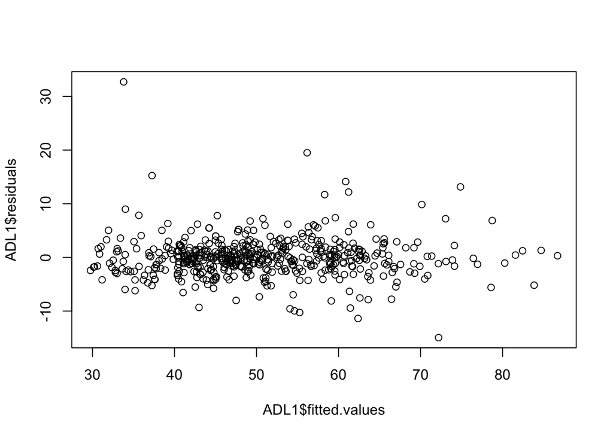

```r
plot(ADL1$fitted.values,ADL1$residuals)
```

Or we can use the `plot()` function, specifying the fit object. Set the which argument=1 to replicate the previous plot. The advantage of this plot is that it identifies the dates of outliers.

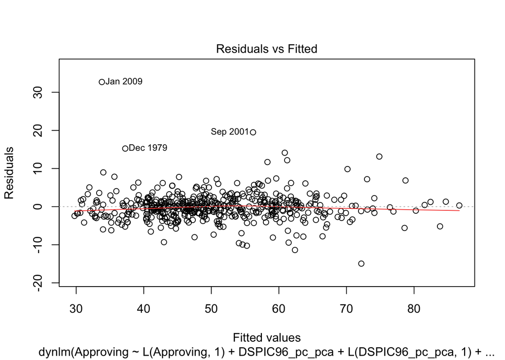

```r
plot(ADL1, which=1)
```

#### The Breusch-Pagan Test for Heteroscedasticity

Breusch and Pagan developed an LM test for heteroscedasticity in which we fit an auxiliary regression where the squared residuals are regressed on the explanatory variables in the original model. Assume again we have estimated the ADL(1,1;2) model given above. Estimate the auxiliary regression of $\hat{e^2}_t$ on the regressors included in the original regression.

$$\begin{equation}
\hat{e^2}_t = \gamma_{00} + \pi_{11}y_{t-1} + \gamma_{10} x_{1,t} + \gamma_{11}x_{1,t-1} +\gamma_{20} x_{2,t} + \gamma_{21}x_{2,t-1} + v_t
\end{equation}$$
where $\hat{e}_t$ are the residuals from the original regression.

The null hypothesis for the test is thus $\pi_{11} = \gamma_{10}=...=\gamma_{21}=0$. If the coefficient on any of the regressors is different from zero, then the variance is heteroscedastic. If they are jointly zero, $R^2$ of the model will be zero and the variance is (linearly) homoscedastic.

The regression can be used to compute a Lagrange multiplier test statistic given by $TR^2$, where $T$ is the number of observations in the auxiliary regression and $R^2$ is computed from the auxiliary regression. The test statistic is distributed $\chi^2$ with $n$ degrees of freedom where $n$ is the number of regressors in the auxiliary regression. As with the LM test for serial correlation, the LM test statistic will be larger as the explanatory power of the regressors grows, in which case we are more likely to reject the null hypothesis and conclude the disturbances are heteroscedastic.

If the null hypothesis is rejected using these or alternative tests, the typical solution is to apply heteroscedasticity robust standard errors (also known as White or Huber-White standard errors) to the original regression (White 1980, Huber 1967). Heteroscedasticity robust standard errors use the squared residuals from the estimated regression model to estimate the error variances associated with each observation, which are then are used to produce consistent estimates of the standard errors. The use of heteroscedastic-consistent standard errors has become standard in applications where heteroscedasticity is suspected.

We use the `bptest()` function in the lmtest package. The only argument you will need is the model fit object.

bptest(formula, varformula = NULL, studentize = TRUE, data = list())

- `formula` a symbolic description for the model to be tested (or a fitted “lm” object).
- `varformula` a formula describing only the potential explanatory variables for the variance (no dependent variable needed). By default the same explanatory variables are taken as in the main regression model.
- `studentize` If set to TRUE Koenker’s studentized version of the test statistic will be used.
- `data` an optional data frame containing the variables in the model. By default the variables are taken from the environment which bptest is called from.

```r
bptest(ADL1)
```

```
##
##  studentized Breusch-Pagan test
##
## data:  ADL1
## BP = 41.882, df = 10, p-value = 7.869e-06
```

It appears we have heteroscedasticity! The values of our regressors predict the variance of the residuals.

Let’s reestimate the model with the additional intervention variables and retest.

```r
ADL2 <- dynlm(Approving~L(Approving,1) +  DSPIC96_pc_pca +L(DSPIC96_pc_pca, c(1,2))+ lei_pc + L(lei_pc, c(1,2)) + cei_pc + L(cei_pc, c(1,2))
               + Reagan + BushI + Clinton + BushII + Obama + Trump  + Honey + Inaug +  RAss + IraqKuwait + Desert + Lehman + Sept11 + Mueller  + Impeach1 + Impeach2 + CovidP + CovidS + ObamaJan + BushJan  + hostages, data=AppEcon.ts)

summary(ADL2)
```

```
##
## Time series regression with "ts" data:
## Start = 1978(3), End = 2020(12)
##
## Call:
## dynlm(formula = Approving ~ L(Approving, 1) + DSPIC96_pc_pca +
##     L(DSPIC96_pc_pca, c(1, 2)) + lei_pc + L(lei_pc, c(1, 2)) +
##     cei_pc + L(cei_pc, c(1, 2)) + Reagan + BushI + Clinton +
##     BushII + Obama + Trump + Honey + Inaug + RAss + IraqKuwait +
##     Desert + Lehman + Sept11 + Mueller + Impeach1 + Impeach2 +
##     CovidP + CovidS + ObamaJan + BushJan + hostages, data = AppEcon.ts)
##
## Residuals:
##      Min       1Q   Median       3Q      Max
## -14.1210  -1.5753  -0.0798   1.6787  12.9892
##
## Coefficients:
##                              Estimate Std. Error t value Pr(>|t|)
## (Intercept)                   3.73401    1.51235   2.469 0.013894 *
## L(Approving, 1)               0.89979    0.01497  60.125  < 2e-16 ***
## DSPIC96_pc_pca                0.28213    0.16697   1.690 0.091732 .
## L(DSPIC96_pc_pca, c(1, 2))1   0.50943    0.17462   2.917 0.003695 **
## L(DSPIC96_pc_pca, c(1, 2))2   0.37102    0.16368   2.267 0.023849 *
## lei_pc                       11.06463   28.80112   0.384 0.701019
## L(lei_pc, c(1, 2))1         -20.91583   29.98909  -0.697 0.485859
## L(lei_pc, c(1, 2))2         -24.10537   30.14510  -0.800 0.424311
## cei_pc                       24.38622   32.96839   0.740 0.459851
## L(cei_pc, c(1, 2))1          41.70758   33.86453   1.232 0.218699
## L(cei_pc, c(1, 2))2         121.12939   33.05591   3.664 0.000275 ***
## Reagan                        2.19396    0.66271   3.311 0.001001 **
## BushI                         2.06765    0.79204   2.611 0.009322 **
## Clinton                       2.25228    0.66822   3.371 0.000810 ***
## BushII                        1.18734    0.64656   1.836 0.066914 .
## Obama                         1.70956    0.65631   2.605 0.009477 **
## Trump                         0.13776    0.78167   0.176 0.860177
## Honey                         0.13607    0.06420   2.120 0.034550 *
## Inaug                        -0.52377    1.72798  -0.303 0.761937
## RAss                          7.09311    3.15988   2.245 0.025238 *
## IraqKuwait                    1.97725    1.54024   1.284 0.199853
## Desert                       10.93931    1.90026   5.757 1.53e-08 ***
## Lehman                       -0.09490    3.19840  -0.030 0.976343
## Sept11                       11.30427    1.65087   6.847 2.30e-11 ***
## Mueller                       7.84332    3.14129   2.497 0.012863 *
## Impeach1                      3.24988    3.14194   1.034 0.301488
## Impeach2                      2.83867    3.14603   0.902 0.367346
## CovidP                        1.46048    3.73287   0.391 0.695787
## CovidS                       -1.10023    1.24731  -0.882 0.378171
## ObamaJan                     33.92420    3.55616   9.540  < 2e-16 ***
## BushJan                     -12.22733    3.50289  -3.491 0.000526 ***
## hostages                     17.67062    3.14595   5.617 3.29e-08 ***
## ---
## Signif. codes:  0 '***' 0.001 '**' 0.01 '*' 0.05 '.' 0.1 ' ' 1
##
## Residual standard error: 3.088 on 482 degrees of freedom
## Multiple R-squared:  0.9286, Adjusted R-squared:  0.924
## F-statistic: 202.2 on 31 and 482 DF,  p-value: < 2.2e-16
```

```r
bptest(ADL2)
```

```
##
##  studentized Breusch-Pagan test
##
## data:  ADL2
## BP = 124.97, df = 31, p-value = 3.079e-13
```

This didn’t solve the problem, but as the coefficients are significant we will use heteroscedastic robust standard errors for hypothesis testing.

### A Word on Heteroscedastic and Autocorrelation Consistent Standard Errors

Newey (1987 and 1994) extended the logic of heteroscedastic robust standard error estimation to also allow for violations of the no serial correlation assumption to produce heteroscedastic and autocorrelation consistent, or HAC, standard errors. The use of HAC standard errors is common in time series regressions with strictly exogenous regressors and they are applied in many unit root tests. They are not, however, frequently used in dynamic regressions with weakly exogenous regressors because serial correlation is generally treated as evidence of dynamic misspecification and because HAC standard errors are often so large as render them useless. It is always possible, however, that the regression disturbances are serially correlated and heteroscedastic such that use of the combined heteroscedastic-autocorrelation-consistent, or HAC, standard errors may be a good strategy. In cases where ATS5 and ATS6 are not violated, the HAC standard errors will be equivalent to their OLS counterparts that assume serially uncorrelated and homoscedastic disturbances.

```r
ADL2H <- coeftest(ADL2, vcov = vcovHAC(ADL2))# Heteroscedastic and autocorrelation consistent covariance matrix
ADL2HAC <-coeftest(ADL2, vcov = vcovHC(ADL2, type="HC1")) # Heteroscedastic consistent covariance matrix
```

```r
LM2SE <-stargazer(ADL2, ADL2H, ADL2HAC,
                     type = "html",
                     title="ADL Regression Results",
                     align=TRUE,
                     style="ajs",
                  column.labels =c("Normal SE", "H-Robust SE", "HAC SE"),
                  dep.var.labels = c("Approval","Approval","Approval"),
                  model.names = FALSE
                  )
```

**ADL Regression Results**

[output not shown]

### Other Diagnostic Tests

The OLS standard errors are asymptotically valid if ATS1-5 hold. If the residuals are normally distributed in sample, then they hold exactly. We’ve already seen evidence that the residuals are not normally distributed, likely due to a few outliers. We can test this formally using the `jarque.bera.test()` function in the tseries package. The only argument is the residuals from the estimated model fit. Note, however, that unless the residuals are wildly non-normal, we can proceed without much threat to inference.

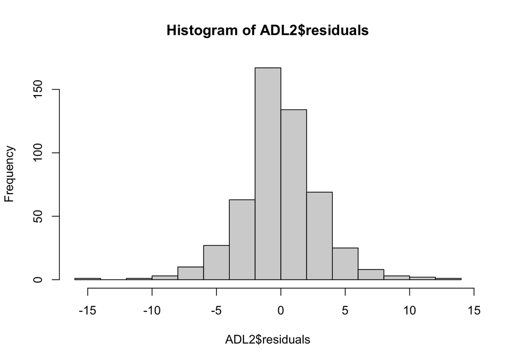

```r
hist(ADL2$residuals)
```

```r
jarque.bera.test(ADL2$residuals)
```

```
##
##  Jarque Bera Test
##
## data:  ADL2$residuals
## X-squared = 128.71, df = 2, p-value < 2.2e-16
```

Ramsey’s RESET is a regression specification error test testing the zero conditional mean assumption. It tests whether squares and cubes of the regressors predict the residuals (and thus $y_t$). This function `resettest()` is also in the lmtest package. The first argument is the linear model fit object and we specify type=“regressor”.

```r
resettest(ADL2, type="regressor")
```

```
##
##  RESET test
##
## data:  ADL2
## RESET = 0.46708, df1 = 62, df2 = 420, p-value = 0.9998
```

**It is a good strategy, if you have enough time points, to estimate the model on subsets of the data to see if the coefficients are stable. If not, likely you are missing something in the model specification!**

We can use the `checkresiduals()` function in the forecast package to provide a set of diagnostics.

checkresiduals(object, lag, df = NULL, test, plot = TRUE, …)

- `object`Either a time series model, a forecast object, or a time series (assumed to be residuals).
- `lag` Number of lags to use in the Ljung-Box or Breusch-Godfrey test. If missing, it is set to min(10,n/5) for non-seasonal data, and min(2m, n/5) for seasonal data, where n is the length of the series, and m is the seasonal period of the data. It is further constrained to be at least df+3 where df is the degrees of freedom of the model. This ensures there are at least 3 degrees of freedom used in the chi-squared test.
- `df`Number of degrees of freedom for fitted model, required for the Ljung-Box or Breusch-Godfrey test. Ignored if the degrees of freedom can be extracted from object.
- `test` Test to use for serial correlation. By default, if object is of class lm, then test=“BG”. Otherwise, test=“LB”. Setting test=FALSE will prevent the test results being printed.
- `plot` If TRUE, will produce the plot.

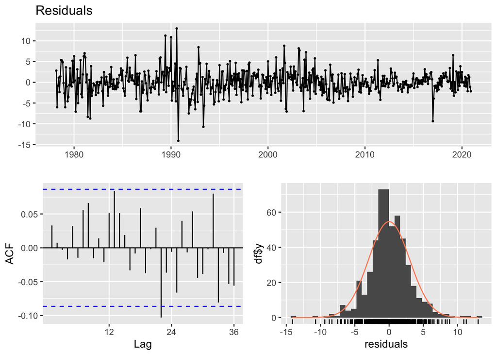

```
##
##  Breusch-Godfrey test for serial correlation of order up to 12
##
## data:  Residuals
## LM test = 8.5067, df = 12, p-value = 0.7444
```

```r
library(forecast)
checkresiduals(ADL2, lag=12,test="BG")
```